# What We’ve Learned

November 18, 2020

## ANOVA

- One-way ANOVA: one categorical explanatory variable
- Two-way ANVOA: two categorical explanatory variables
  - Goal: describe the means of different groups, and identify whether they are similar or different

## One-way ANOVA

[figure not shown]

## Model Hypotheses

\(H_0\): all of the group means are the same in the population

- \(\mu_{1970} = \mu_{1980} = \mu_{1990} = \mu_{2000}\)
- There is no difference in the mean rating between different years, for all movies made between 1970 and 2009

\(H_A\): at least one of the means differs in the population

- At least one \(\mu_i\) differs
- The mean movie rating for at least on era is different, for all movies made between 1970 and 2009.

## To Permute or F it?

To conduct a hypothesis test, you have two choices:

1. permute the movie ratings assuming the null hypothesis is true
2. use an F-distribution as an approximation to the null distribution

Why would you choose one over the other?

What is the difference in how you obtain your p-value?

## Model Conclusions

For Movie Eras:

```
## # A tibble: 2 x 6
##   term         df  sumsq meansq statistic p.value
##   <chr>     <dbl>  <dbl>  <dbl>     <dbl>   <dbl>
## 1 era           3   4.59   1.53     0.669   0.575
## 2 Residuals    52 119.     2.28    NA      NA
```

- There is no evidence that the mean movie rating differs across the different eras.

## Multiple Comparison - Post Hoc

If we reject \(H_0\) in a one-way ANOVA, we may be interested in *which* means differ from each other.

- Multiple comparisons allow for us to test all possible combinations of two means, to see which means differ.
- Different from looking at a plot and deciding which means you want to compare!
- Lots of hypothesis tests \(\rightarrow\) increased Type I error rates
  - Remedy with “family” \(\alpha\) values
  - Adjust p-values based on the number of tests performed

## Two-way ANOVA

[figure not shown]

**Goal**

Assess if the relationship between one categorical explanatory variable and the response *differs* based on the values of another categorical variable

## Additive Model

- Each of the explanatory variables (possibly) has an impact
- The impact of one explanatory variable is the same for all levels of the other explanatory variable
- Similar to parallel slopes in a multiple linear regression!

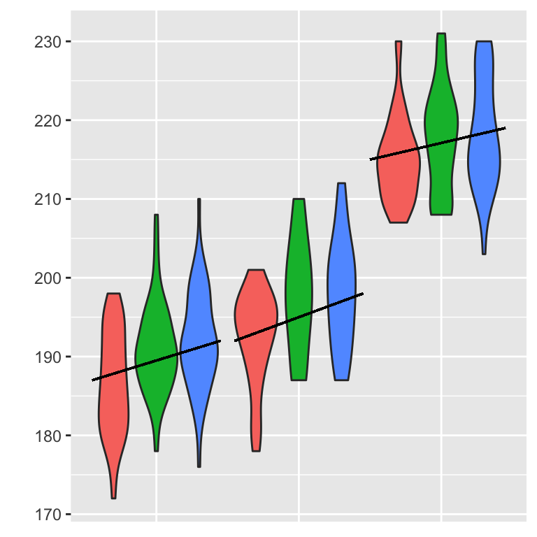

## Interactive Model

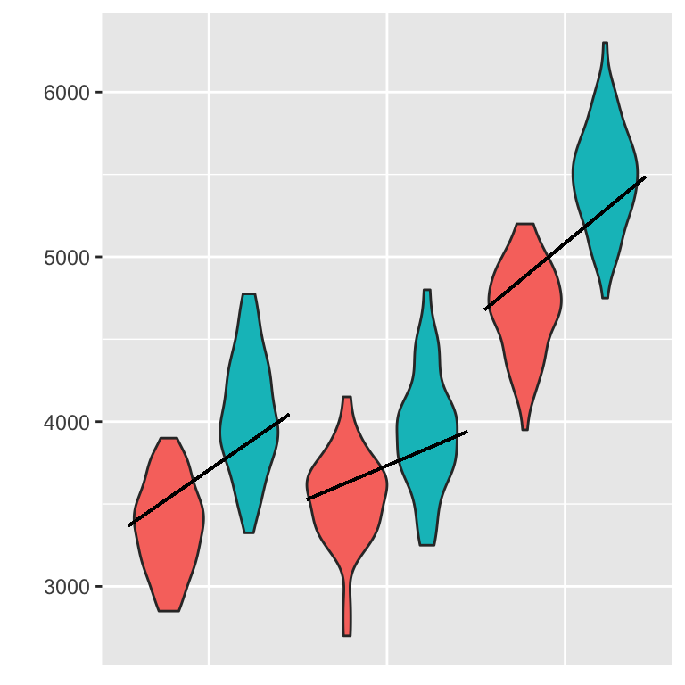

- The impact of one explanatory variable differs based on the level of the other explanatory variable
- Similar to different slopes in a multiple linear regression!

## Hypothesis Test Steps

1. Fit an interaction model
2. Decide if the interaction is necessary
   - If yes, then this is your model!
   - If no, remove the interaction term!

```
## # A tibble: 4 x 6
##   term         df  sumsq meansq statistic p.value
##   <chr>     <dbl>  <dbl>  <dbl>     <dbl>   <dbl>
## 1 era           3   4.59   1.53     0.659   0.581
## 2 genre         1   4.19   4.19     1.81    0.185
## 3 era:genre     3   3.32   1.11     0.477   0.700
## 4 Residuals    48 111.     2.32    NA      NA
```

1. Fit an additive model
2. Decide if each explanatory variable is necessary

```
## # A tibble: 3 x 6
##   term         df  sumsq meansq statistic p.value
##   <chr>     <dbl>  <dbl>  <dbl>     <dbl>   <dbl>
## 1 era           3   4.59   1.53     0.680   0.568
## 2 genre         1   4.19   4.19     1.86    0.178
## 3 Residuals    51 115.     2.25    NA      NA
```

What would our final model be?

## What We’ve Learned

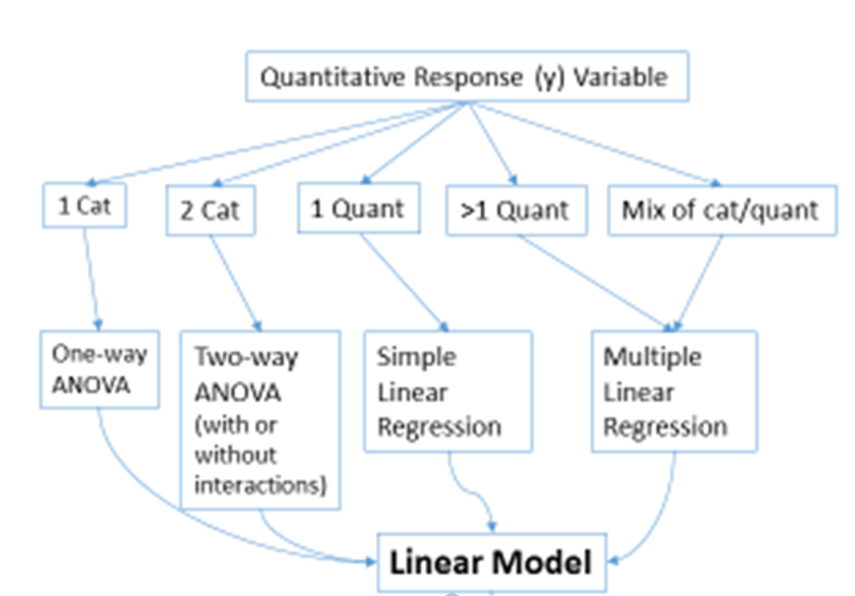

## Key Ideas

- Reproducibility is a foundational aspect to scientific research.
- Data visualizations tell you a story, where statistical tests only tell you a summary.
- Multiple regression is a powerful tool to explore multivariate relationships.
- A well thought out study is more powerful than any statistical analysis.

## Code Used in This Presentation

## One-way ANOVA

```r
movies %>%
  ggplot(aes(x = era, y = rating, fill = era)) +
  geom_violin() +
  scale_fill_brewer(palette = "Paired") +
  labs(x = "Year of Movie Release",
       y = "IMDB Moving Rating") +
  theme(legend.position = "none")

movies %>%
  ggplot(aes(x = genre, y = rating, fill = genre)) +
  geom_violin() +
  scale_fill_brewer(palette = "Dark2") +
  labs(x = "Year of Movie Release",
       y = "") +
  theme(legend.position = "none")

aov(rating ~ era, data = movies) %>%
  tidy()
```

## Two-way ANOVA

```r
movies %>%
  ggplot(aes(x = era, y = rating)) +
  geom_violin(aes(fill = genre)) +
  scale_fill_brewer(palette = "Paired") +
  labs(x = "Year of Movie Release",
       y = "IMDB Moving Rating",
       fill = "Movie Genre")

aov(rating ~ era*genre, data = movies) %>%
  tidy()

aov(rating ~ era + genre, data = movies) %>%
  tidy()
```